# 算法训练营Day 30

Author

Siru Wu

Published

March 1, 2026

## [452. 用最少数量的箭引爆气球](https://leetcode.cn/problems/minimum-number-of-arrows-to-burst-balloons/description/)

> 有一些球形气球贴在一堵用 XY 平面表示的墙面上。墙面上的气球记录在整数数组 points ，其中points[i] = [xstart, xend] 表示水平直径在 xstart 和 xend之间的气球。你不知道气球的确切 y 坐标。

> 一支弓箭可以沿着 x 轴从不同点 完全垂直 地射出。在坐标 x 处射出一支箭，若有一个气球的直径的开始和结束坐标为 xstart，xend， 且满足 xstart ≤ x ≤ xend，则该气球会被 引爆 。可以射出的弓箭的数量 没有限制 。 弓箭一旦被射出之后，可以无限地前进。

> 给你一个数组 points ，返回引爆所有气球所必须射出的 最小 弓箭数 。

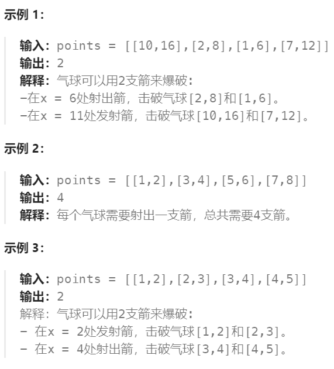

```python
class Solution:
    def findMinArrowShots(self, points: List[List[int]]) -> int:
        if len(points) == 0: return 0
        points.sort(key=lambda x: x[0])
        result = 1
        for i in range(1, len(points)):
          # 比较左边气球的右边界 和 右边气球的左边界，如果右边气球的左边界 > 左边气球的右边界,说明这两个气球一定没有重叠，那么就要多用一只箭
            if points[i][0] > points[i - 1][1]: # 气球i和气球i-1不挨着，注意这里不是>=
                result += 1
            else:
                points[i][1] = min(points[i - 1][1], points[i][1]) # 更新重叠气球最小右边界
        return result
```

## [435. 无重叠区间](https://leetcode.cn/problems/non-overlapping-intervals/description/)

> 给定一个区间的集合 intervals ，其中 intervals[i] = [starti, endi] 。返回 需要移除区间的最小数量，使剩余区间互不重叠 。

> 注意 只在一点上接触的区间是 不重叠的。例如 [1, 2] 和 [2, 3] 是不重叠的。

> **示例 1:**
> - 输入: intervals = [[1,2],[2,3],[3,4],[1,3]]
> - 输出: 1
> - 解释: 移除 [1,3] 后，剩下的区间没有重叠。

> **示例 2:**
> - 输入: intervals = [ [1,2], [1,2], [1,2] ]
> - 输出: 2
> - 解释: 你需要移除两个 [1,2] 来使剩下的区间没有重叠。

> **示例 3:**
> - 输入: intervals = [ [1,2], [2,3] ]
> - 输出: 0
> - 解释: 你不需要移除任何区间，因为它们已经是无重叠的了。

### 版本一

```python
class Solution:
    def eraseOverlapIntervals(self, intervals: List[List[int]]) -> int:
        if not intervals:
            return 0

        intervals.sort(key=lambda x: x[0])  # 按照左边界升序排序
        count = 0  # 记录重叠区间数量

        for i in range(1, len(intervals)):
            if intervals[i][0] < intervals[i - 1][1]:  # 存在重叠区间
                intervals[i][1] = min(intervals[i - 1][1], intervals[i][1])  # 更新重叠区间的右边界
                count += 1

        return count
```

### 版本二：修改重叠区域气球的code

```python
class Solution:
    def eraseOverlapIntervals(self, intervals: List[List[int]]) -> int:
        if not intervals:
            return 0

        intervals.sort(key=lambda x: x[0])  # 按照左边界升序排序

        result = 1  # 不重叠区间数量，初始化为1，因为至少有一个不重叠的区间

        for i in range(1, len(intervals)):
            if intervals[i][0] >= intervals[i - 1][1]:  # 没有重叠
                result += 1
            else:  # 重叠情况
                intervals[i][1] = min(intervals[i - 1][1], intervals[i][1])  # 更新重叠区间的右边界

        return len(intervals) - result
```

## [763.划分字母区间](https://leetcode.cn/problems/partition-labels/description/)

> 给你一个字符串 s 。我们要把这个字符串划分为尽可能多的片段，同一字母最多出现在一个片段中。例如，字符串 “ababcc” 能够被分为 [“abab”, “cc”]，但类似 [“aba”, “bcc”] 或 [“ab”, “ab”, “cc”] 的划分是非法的。

> 注意，划分结果需要满足：将所有划分结果按顺序连接，得到的字符串仍然是 s 。

> 返回一个表示每个字符串片段的长度的列表。

> **示例 1：**
> - 输入：s = “ababcbacadefegdehijhklij”
> - 输出：[9,7,8]
> - 解释：

> 划分结果为 “ababcbaca”、“defegde”、“hijhklij” 。

> 每个字母最多出现在一个片段中。

> 像 “ababcbacadefegde”, “hijhklij” 这样的划分是错误的，因为划分的片段数较少。

> **示例 2：**
> - 输入：s = “eccbbbbdec”
> - 输出：[10]

```python
class Solution:
    def partitionLabels(self, s: str) -> List[int]:
        last_occurrence = {}  # 存储每个字符最后出现的位置
        for i, ch in enumerate(s): # ch表示字母，i表示字母出现的位置
            last_occurrence[ch] = i # 更新每个 ch（字母）最后出现的 i (位置)

        result = []
        start = 0
        end = 0
        for i, ch in enumerate(s):
            end = max(end, last_occurrence[ch])  # 找到当前字符出现的最远位置
            if i == end:  # 如果当前位置是最远位置，表示可以分割出一个区间
                result.append(end - start + 1) # 因为题目要求我们返回每一段的长度，不是返回分段字符串，所以这里我们只用记录每一段的len
                start = i + 1

        return result
```